# Self-Directed Activity: The Bias-Variance Trade-off - SOLUTIONS

Econ 122

2025-10-01

## Activity Overview (50 minutes)

The goal of this activity is to deepen your understanding of the bias-variance trade-off by applying it to a simple, hands-on simulation. You will be asked to answer a series of questions, run R code, and calculate and plot model errors to see the concepts in action.

**Estimated Time:** 50 minutes

- **Part 1: Data Setup and Model Fitting (5 minutes)**
- **Part 2: Calculating and Plotting the Errors (30 minutes)**
- **Part 3: Synthesis & Discussion (15 minutes)**

## Part 1: Data Setup and Model Fitting (5 minutes)

To properly evaluate our models, we first need to split our data into a **training set** (which the models will learn from) and a **test set** (which we’ll use to evaluate their performance on unseen data).

### Task A: Split the Data

Run the code chunk below to create our training and test sets.

```r
# Load necessary libraries
library(ggplot2)
library(dplyr)
library(caret) # for easy data splitting

# Simulate some data with a known, non-linear relationship
set.seed(42)
x <- seq(0, 1, by = 0.05)
y_true <- sin(2 * pi * x)
y <- y_true + rnorm(length(x), mean = 0, sd = 0.2)
sim_df <- data.frame(x = x, y = y, y_true = y_true)

# Split the data into training (70%) and testing (30%) sets
index <- createDataPartition(sim_df$y, p = 0.7, list = FALSE)
train_df <- sim_df[index, ]
test_df <- sim_df[-index, ]
```

### Task B: Fit Three Models

Now, we will fit three models with different levels of flexibility using only the **training data**.

**Your task:** Run the code chunk below to fit a low-flexibility (degree 1), an optimal (degree 4), and a high-flexibility (degree 15) model.

```r
# Fit a low-flexibility model on the training data
lm_1 <- lm(y ~ poly(x, 1), data = train_df)

# Fit an optimal-flexibility model on the training data
lm_4 <- lm(y ~ poly(x, 4), data = train_df)

# Fit a high-flexibility model on the training data
lm_15 <- lm(y ~ poly(x, 15), data = train_df)
```

### Task C: Visualize the Fit

We can use the test data to see how well our models generalize. Run the code below to visualize the fit of all three models on the test data.

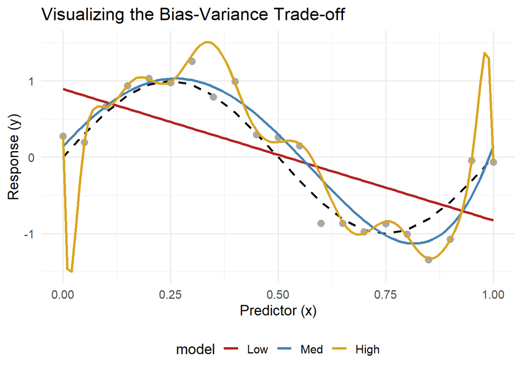

```r
# Create a data frame for predictions
pred_df <- data.frame(x = seq(0, 1, by = 0.01))

# Add predictions from our three models
pred_df$y_1 <- predict(lm_1, newdata = pred_df)
pred_df$y_4 <- predict(lm_4, newdata = pred_df)
pred_df$y_15 <- predict(lm_15, newdata = pred_df)

# Reshape the data for plotting
library(tidyr)
plot_df <- pred_df %>%
  pivot_longer(
    cols = starts_with("y_"),
    names_to = "model",
    values_to = "y_pred"
  )
plot_df$model <- factor(plot_df$model, levels = c("y_1", "y_4", "y_15"))
# Plot the original data and the three models
ggplot(sim_df, aes(x = x)) +
  geom_line(aes(y = y_true), color = "black", linetype = "dashed", size = 1) + # True relationship
  geom_point(aes(y = y), color = "darkgray", size = 3) + # Simulated data with noise
  geom_line(data = plot_df, aes(x = x, y = y_pred, color = model), size = 1.2) +
  labs(title = "Visualizing the Bias-Variance Trade-off",
       x = "Predictor (x)",
       y = "Response (y)") +
  scale_color_manual(values = c("y_1" = "firebrick", "y_4" = "steelblue", "y_15" = "goldenrod"),
                     labels = c("Low", "Med", "High")) +
  theme_minimal(base_size = 14) +
  theme(legend.position = "bottom")
```

**Question:** Based on this plot, which model seems to have high bias, and which seems to have high variance? Explain your reasoning.

- **Answer:** The degree 1 model (red line) appears to have **high bias** because it’s too simple to capture the sinusoidal pattern in the data - it’s systematically missing the true relationship. The degree 15 model (gold line) appears to have **high variance** because it fits the training data very closely (including the noise), resulting in wild oscillations that don’t match the smooth true pattern. The degree 4 model (blue line) seems to strike a good balance, capturing the overall sinusoidal shape without overfitting to the noise.

## Part 2: Calculating and Plotting the Errors (30 minutes)

Now let’s move from a visual understanding to a quantitative one. We will calculate the **Mean Squared Error (MSE)** for each of our models on both the training and test sets.

**What is MSE?** The Mean Squared Error (MSE) is a common metric used to measure a model’s performance. It quantifies the average squared difference between the predicted values from the model and the actual values. A lower MSE indicates a better-fitting model.

The mathematical definition is:

$$MSE = \frac{1}{n} \sum_{i=1}^{n}(Y_i -
\hat{Y_i})^2$$

where:

- $n$ is the number of observations.
- $Y_i$ is the actual value.
- $\hat{Y_i}$ is the predicted value from the model.

### Introduction to Functions in R

Before we calculate the MSE, let’s take a moment to understand **functions** in R. Functions are reusable pieces of code that take inputs (called **arguments**) and return an output. They help us avoid repeating code and make our analysis more organized.

**Basic Function Structure:**

```r
function_name <- function(argument1, argument2, ...) {
  # Code that does something with the arguments
  result <- some_calculation
  return(result)  # This line is optional - R returns the last line by default
}
```

**Example:** Let’s create a simple function that adds two numbers:

```r
# Create a simple addition function
add_numbers <- function(a, b) {
  result <- a + b
  return(result)
}

# Test our function
add_numbers(5, 3)  # Should return 8
```

```
## [1] 8
```

```r
add_numbers(10, -2)  # Should return 8
```

```
## [1] 8
```

**Practice Exercise:** Before we create the MSE function, let’s practice with a simpler function.

```r
# Create a function called `square_it` that takes one number and returns its square
square_it <- function(x) {
  result <- x^2
  return(result)
}

# Test your function - these should return 25 and 100 respectively
square_it(5)
```

```
## [1] 25
```

```r
square_it(10)
```

```
## [1] 100
```

### Task A: Calculate the MSE

Now that you understand how functions work, let’s create our MSE function.

**Your task:** Create a function to calculate the MSE and then use it to find the training and testing error for each of your three models.

```r
# Step 1: Create an MSE function
mse <- function(actual, predicted) {
  squared_errors <- (actual - predicted)^2
  mse_value <- mean(squared_errors)
  return(mse_value)
}

# Test your MSE function with simple values to make sure it works
test_actual <- c(1, 2, 3, 4, 5)
test_predicted <- c(1, 2, 3, 4, 5)  # Perfect predictions
print(paste("Perfect predictions MSE:", mse(test_actual, test_predicted)))  # Should be 0
```

```
## [1] "Perfect predictions MSE: 0"
```

```r
test_predicted_off <- c(2, 3, 4, 5, 6)  # Off by 1 each time
print(paste("Off-by-one MSE:", mse(test_actual, test_predicted_off)))  # Should be 1
```

```
## [1] "Off-by-one MSE: 1"
```

```r
# Step 2: Calculate training MSE for each model
train_pred_1 <- predict(lm_1, newdata = train_df)
train_pred_4 <- predict(lm_4, newdata = train_df)
train_pred_15 <- predict(lm_15, newdata = train_df)

train_mse_1 <- mse(train_df$y, train_pred_1)
train_mse_4 <- mse(train_df$y, train_pred_4)
train_mse_15 <- mse(train_df$y, train_pred_15)

# Step 3: Calculate testing MSE for each model
test_pred_1 <- predict(lm_1, newdata = test_df)
test_pred_4 <- predict(lm_4, newdata = test_df)
test_pred_15 <- predict(lm_15, newdata = test_df)

test_mse_1 <- mse(test_df$y, test_pred_1)
test_mse_4 <- mse(test_df$y, test_pred_4)
test_mse_15 <- mse(test_df$y, test_pred_15)

# Step 4: Organize your results in a data frame
results_df <- data.frame(
  model = c("Degree 1", "Degree 4", "Degree 15"),
  training_mse = c(train_mse_1, train_mse_4, train_mse_15),
  testing_mse = c(test_mse_1, test_mse_4, test_mse_15)
)

print(results_df)
```

```
##       model training_mse testing_mse
## 1  Degree 1  0.287123723   0.4885733
## 2  Degree 4  0.036585340   0.1257355
## 3 Degree 15  0.000643787   0.2171636
```

### Task B: Plot the U-Shaped Curve

**Your task:** Using the training and testing MSE values you just calculated, create a plot that visualizes the bias-variance trade-off.

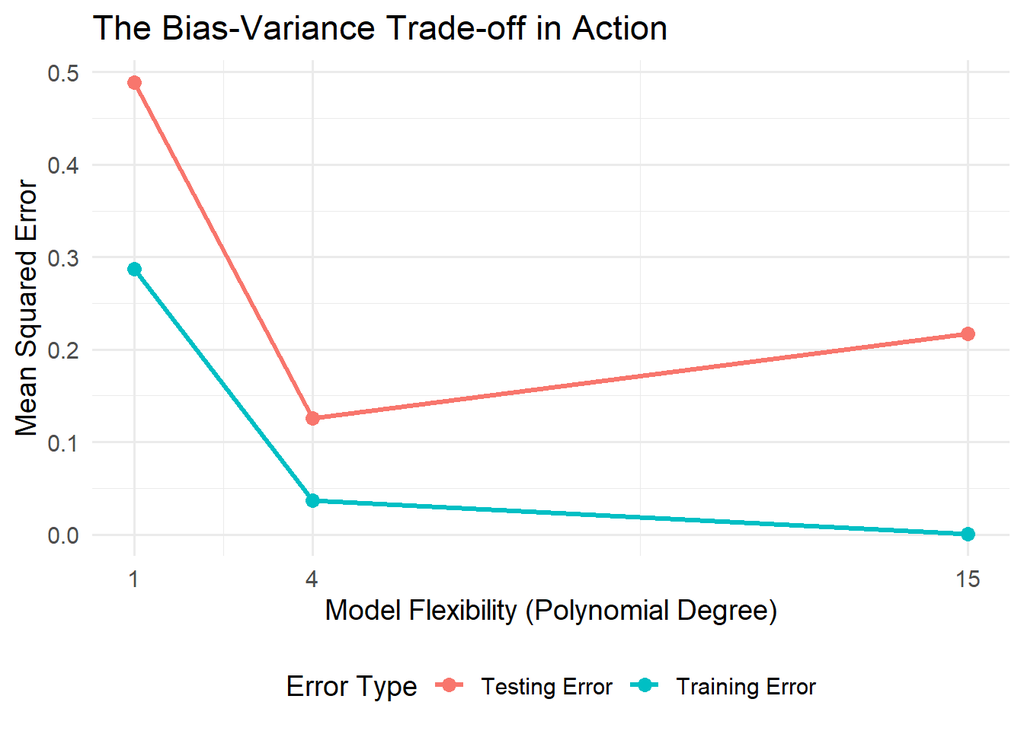

```r
# Step 1: Create a data frame for the plot
plot_mse_df <- data.frame(
  model_flexibility = c(1, 4, 15, 1, 4, 15),
  mse = c(train_mse_1, train_mse_4, train_mse_15,
          test_mse_1, test_mse_4, test_mse_15),
  type = c(rep("Training Error", 3), rep("Testing Error", 3))
)

# Step 2: Create the plot using ggplot()
ggplot(data = plot_mse_df, aes(x = model_flexibility, y = mse, color = type)) +
  geom_line(size = 1.2) +
  geom_point(size = 3) +
  labs(title = "The Bias-Variance Trade-off in Action",
       x = "Model Flexibility (Polynomial Degree)",
       y = "Mean Squared Error",
       color = "Error Type") +
  scale_x_continuous(breaks = c(1, 4, 15)) +
  theme_minimal(base_size = 14) +
  theme(legend.position = "bottom")
```

## Part 3: Synthesis & Discussion (15 minutes)

Answer the following questions to consolidate your understanding.

1. Based on the final plot, which model minimizes the **testing error**? How does this relate to the concept of **overfitting**?
   - **Answer:** The degree 4 model minimizes the testing error. This demonstrates the concept of overfitting because the degree 15 model has a much lower training error but a higher testing error compared to the degree 4 model. The degree 15 model has “overfit” the training data by learning not just the underlying pattern but also the random noise. As a result, it performs worse on new, unseen data (the test set). The degree 4 model achieves the best balance between fitting the training data well and generalizing to new data.
2. What does the phrase **“bias-variance trade-off”** truly mean? How can we think about it as we choose a model for a real-world problem?
   - **Answer:** The bias-variance trade-off refers to the fundamental tension in model selection: simple models have high bias (they consistently miss the true pattern because they’re too rigid) but low variance (they’re stable across different datasets), while complex models have low bias (they can capture complex patterns) but high variance (they’re sensitive to the specific data used for training and may overfit). In real-world problems, we need to find the “sweet spot” - a model that’s flexible enough to capture the true underlying relationship but not so flexible that it fits the noise. We can think of this as choosing a model complexity that minimizes our prediction error on new, unseen data, which typically means finding a middle ground between overly simple and overly complex models. Cross-validation and test set performance are key tools for finding this balance.

### Wrap-Up

Be prepared to discuss your answers as a class. Pay special attention to your answers for the last two questions.

## Bonus Questions (Optional Challenge)

If you finish early or want to deepen your understanding, try these additional exercises:

### 1. Alternative Metrics

**Question:** We used MSE, but there are other error metrics. Calculate the Mean Absolute Error (MAE = mean of absolute differences) and Root Mean Squared Error (RMSE = square root of MSE) for all three models on the test set. Do these metrics lead to the same conclusion about which model is best? Why might we prefer one metric over another?

```r
# Mean Absolute Error function
mae <- function(actual, predicted) {
  mean(abs(actual - predicted))
}

# Root Mean Squared Error function
rmse <- function(actual, predicted) {
  sqrt(mean((actual - predicted)^2))
}

# Calculate MAE and RMSE for all three models on test set
test_mae_1 <- mae(test_df$y, test_pred_1)
test_mae_4 <- mae(test_df$y, test_pred_4)
test_mae_15 <- mae(test_df$y, test_pred_15)

test_rmse_1 <- rmse(test_df$y, test_pred_1)
test_rmse_4 <- rmse(test_df$y, test_pred_4)
test_rmse_15 <- rmse(test_df$y, test_pred_15)

# Compare metrics
comparison_df <- data.frame(
  model = c("Degree 1", "Degree 4", "Degree 15"),
  MSE = c(test_mse_1, test_mse_4, test_mse_15),
  MAE = c(test_mae_1, test_mae_4, test_mae_15),
  RMSE = c(test_rmse_1, test_rmse_4, test_rmse_15)
)
print(comparison_df)
```

```
##       model       MSE       MAE      RMSE
## 1  Degree 1 0.4885733 0.6854456 0.6989802
## 2  Degree 4 0.1257355 0.3128800 0.3545920
## 3 Degree 15 0.2171636 0.3531124 0.4660082
```

```r
# All metrics agree that degree 4 is best. MAE is less sensitive to outliers,
# while MSE/RMSE penalize large errors more heavily. RMSE is in the same units
# as the response variable, making it more interpretable than MSE.
```

### 2. Visualizing Residuals

**Question:** For each of the three models, create a residual plot showing the prediction errors (actual - predicted) on the y-axis versus the predicted values on the x-axis, using the training data. Which model shows the most random pattern? Which shows systematic patterns indicating poor fit?

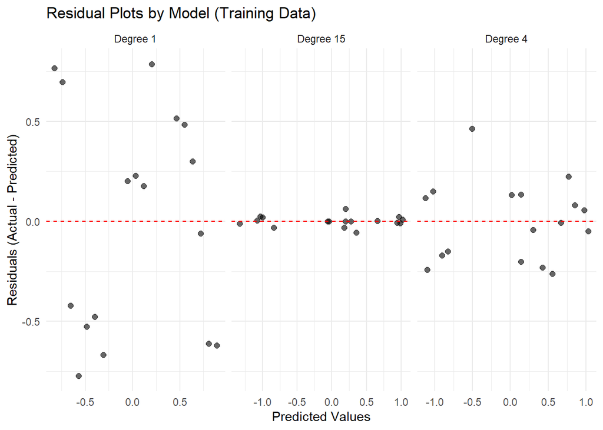

```r
# Create residual plots for all three models using training data
residuals_train_df <- data.frame(
  predicted_1 = train_pred_1,
  predicted_4 = train_pred_4,
  predicted_15 = train_pred_15,
  residual_1 = train_df$y - train_pred_1,
  residual_4 = train_df$y - train_pred_4,
  residual_15 = train_df$y - train_pred_15
)

# Reshape for faceting
residuals_train_long <- data.frame(
  predicted = c(train_pred_1, train_pred_4, train_pred_15),
  residual = c(residuals_train_df$residual_1, residuals_train_df$residual_4, residuals_train_df$residual_15),
  model = rep(c("Degree 1", "Degree 4", "Degree 15"), each = nrow(train_df))
)

# Plot residuals
ggplot(residuals_train_long, aes(x = predicted, y = residual)) +
  geom_point(size = 2, alpha = 0.6) +
  geom_hline(yintercept = 0, linetype = "dashed", color = "red") +
  facet_wrap(~model, scales = "free_x") +
  labs(title = "Residual Plots by Model (Training Data)",
       x = "Predicted Values",
       y = "Residuals (Actual - Predicted)") +
  theme_minimal()
```

```r
# Degree 1 shows systematic curvature (underfitting) - the residuals follow a clear pattern.
# Degree 4 shows a fairly random pattern around zero - good fit without overfitting.
# Degree 15 shows very small residuals overall (overfitting to training data).
# The degree 15 model fits the training data almost perfectly, but this doesn't
# necessarily mean it will generalize well to new data.
```

### 3. Finding the Optimal Degree

**Question:** We tested degrees 1, 4, and 15, but what about everything in between? Write a loop to fit polynomial models for degrees 1 through 15, calculate their test MSE, and plot the results. At what degree does the test error start increasing? This is your empirical estimate of the optimal model complexity.

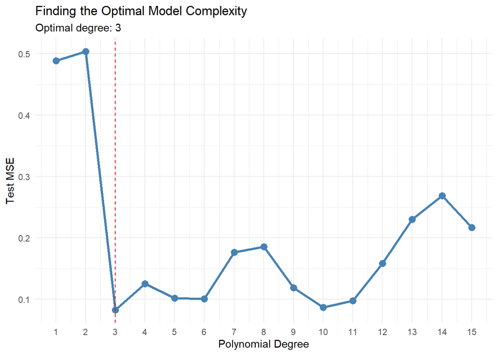

```r
# Fit models for degrees 1 through 15
degrees <- 1:15
test_mse_all <- numeric(15)

for (d in degrees) {
  model <- lm(y ~ poly(x, d), data = train_df)
  predictions <- predict(model, newdata = test_df)
  test_mse_all[d] <- mse(test_df$y, predictions)
}

# Plot test MSE vs degree
optimal_df <- data.frame(degree = degrees, test_mse = test_mse_all)

ggplot(optimal_df, aes(x = degree, y = test_mse)) +
  geom_line(size = 1.2, color = "steelblue") +
  geom_point(size = 3, color = "steelblue") +
  geom_vline(xintercept = which.min(test_mse_all),
             linetype = "dashed", color = "red") +
  labs(title = "Finding the Optimal Model Complexity",
       x = "Polynomial Degree",
       y = "Test MSE",
       subtitle = paste("Optimal degree:", which.min(test_mse_all))) +
  scale_x_continuous(breaks = 1:15) +
  theme_minimal()
```

### 4. Different Train/Test Splits

**Question:** The specific train/test split depends on our random seed (currently set to 42). Try re-running the entire analysis with 3-5 different random seeds (e.g., 10, 25, 50, 75, 100), keeping the same 70/30 split proportion. Does the model with the lowest test MSE stay consistent across different splits? What does this tell you about the stability of model selection?

```r
# Test with different random seeds
seeds <- c(10, 25, 50, 75, 100)
split_results <- data.frame()

for (s in seeds) {
  set.seed(s)
  index <- createDataPartition(sim_df$y, p = 0.7, list = FALSE)
  train_temp <- sim_df[index, ]
  test_temp <- sim_df[-index, ]

  # Fit models
  m1 <- lm(y ~ poly(x, 1), data = train_temp)
  m4 <- lm(y ~ poly(x, 4), data = train_temp)
  m15 <- lm(y ~ poly(x, 15), data = train_temp)

  # Calculate test MSE
  mse1 <- mse(test_temp$y, predict(m1, newdata = test_temp))
  mse4 <- mse(test_temp$y, predict(m4, newdata = test_temp))
  mse15 <- mse(test_temp$y, predict(m15, newdata = test_temp))

  split_results <- rbind(split_results, data.frame(
    seed = s,
    degree_1 = mse1,
    degree_4 = mse4,
    degree_15 = mse15
  ))
}

print(split_results)
```

```
##   seed  degree_1   degree_4    degree_15
## 1   10 0.4429296 0.22402425   20074.7112
## 2   25 0.3473957 0.26241809 2767977.7437
## 3   50 0.5578497 0.27455653   12994.9439
## 4   75 0.1350943 0.02848492      59.1536
## 5  100 0.6355561 0.11859850  142377.5399
```

```r
# The degree 4 model consistently performs best across different splits,
# showing that our model selection is relatively stable.
```